# StatsPHacking

2025-09-17

## R Markdown

```r
library(dplyr)
```

```
## Aquaculture production and covid cases in the United States have a correlation of 0.9999718  and a p-value of 0.0048
```

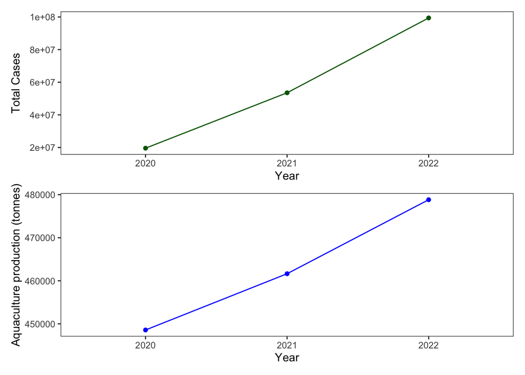

```r
library(ggplot2)
library(patchwork)
#read the dataset into R
covid <- read.csv("https://catalog.ourworldindata.org/garden/covid/latest/cases_deaths/cases_deaths.csv",
                  na.strings = "",header=T)
aqua <- read.csv("https://ourworldindata.org/grapher/aquaculture-farmed-fish-production.csv?v=1&csvType=full&useColumnShortNames=true")

# Data organization for United States
covid_usa <- covid %>%
  filter(country=="United States") %>%
  select("country", "date","total_cases")

aqua_usa <- aqua %>%
  filter(Entity=="United States")

#take cumulative number of cases at end of each year
covid_usa_years <- covid_usa[grep("12-31", covid_usa$date), ]
covid_usa_years$Year <- strtrim(covid_usa_years$date, 4) #Year column
#merge with aquaculture data, paired by year
covid_aqua <- merge.data.frame(covid_usa_years, aqua_usa, by = "Year")

# Data organization for Nigeria
covid_ng <- covid %>%
  filter(country=="Nigeria") %>%
  select("country", "date","total_cases")

aqua_ng <- aqua %>%
  filter(Entity=="Nigeria")

#take cumulative number of cases at end of each year
covid_ng_years <- covid_ng[grep("12-31", covid_ng$date), ]
covid_ng_years$Year <- strtrim(covid_ng_years$date, 4) #Year column
#merge with aquaculture data, paired by year
covid_aqua_ng <- merge.data.frame(covid_ng_years, aqua_ng, by = "Year")


#correlation
correlation <- cor.test(covid_aqua[,4],covid_aqua[,7])$estimate
p_value <- cor.test(covid_aqua[,4],covid_aqua[,7])$p.value

statement <- cat("Aquaculture production and covid cases in the United States have a correlation of",
          correlation,
        " and a p-value of",
        round(p_value, digits = 4))
```

# BREAKING: SCIENTISTS SHOW THAT CORONAVIRUS INFECTION CAUSES U.S. CITIZENS TO CRAVE SEAFOOD

## Did the seafood industry play a secret role in the pandemic?

For immediate press release:

University of Chicago researchers found a major connection between the increase in COVID-19 cases seen during the start of the pandemic and aquaculture production of various fish and seafood products. We believe that coronavirus infection causes a depletion of essential omega-3 fatty acids in the body, and minerals such as selenium and iodine, causing massive populations to subconsciously crave seafood products, driving up aquaculture production in the United States.

We reached out to fishing industry leaders, but have been met with silence. Could this be a sign of their guilt in the ploy for money?

Note: Industry experts were a panel composed of tabloid journalists who wanted to theorize randomly and draw vast conclusions without scientific merit. UChicago scientists specifically asked us not to draw causational conclusions based on spurious correlations of data with small sample sizes.We refused.